# R Notebook

# Relationship between student’s health and abscenses

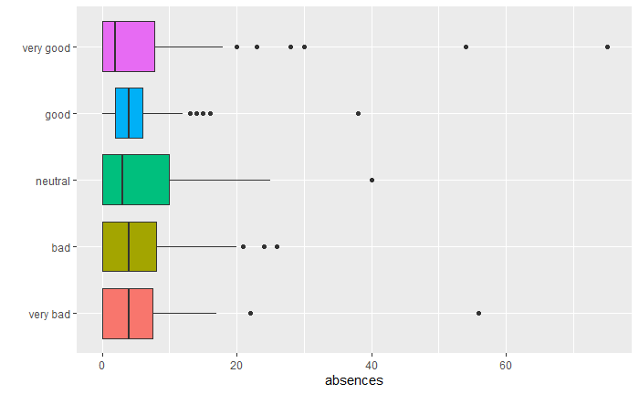

```r
students_health <- students_dataset %>%
  mutate(health = as.factor(health),health_status = recode(health,
                "1" ="very bad",
                "2" = "bad",
                "3" = "neutral",
                "4"=  "good",
                "5"=  "very good")) %>%
  select(absences,health, health_status)



students_health %>%
    ggplot(aes(x = health_status,
           y = absences,
           fill = health_status))+
    geom_boxplot()+coord_flip()+
    xlab("")+theme(legend.position = "none")
```

```r
NA
NA
```

```r
#Separate plots by group
```

```
There were 38 warnings (use warnings() to see them)
```

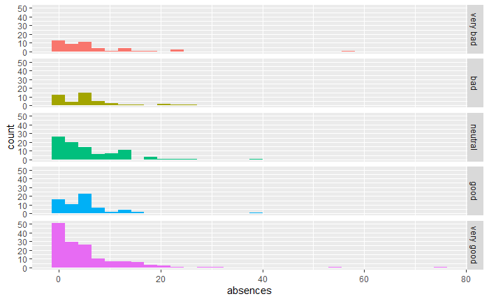

```r
#absences & health_status
students_health %>% ggplot(aes(x = absences, fill = health_status))+geom_histogram()+
facet_grid(health_status ~ .) +
    theme(legend.position = "none")
```

```r
NA
NA
```

#Density plots Final grade in math (G3) & The reaosn of choosing the school (reason)

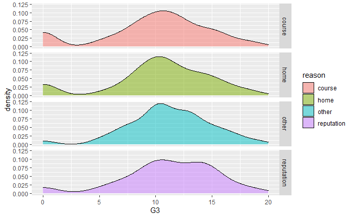

```r
#Final grade in math (G3) & The reaosn of choosing the school (reason)
 students_dataset %>% ggplot(aes(x = G3, fill = reason))+geom_density(alpha=.5)+facet_grid(reason ~ .)
```

```r
    theme(legend.position = "none")
```

```
List of 1
 $ legend.position: chr "none"
 - attr(*, "class")= chr [1:2] "theme" "gg"
 - attr(*, "complete")= logi FALSE
 - attr(*, "validate")= logi TRUE
```

Relation between final grade in math ,consumption of alcohol and the address

```r
Grades_Dalc<-students_dataset %>%group_by(address)%>%ggplot(aes(x=factor(Dalc), y= G3))+geom_jitter(alpha=0.6)+scale_x_discrete("Dalc")+scale_y_continuous("G3")+facet_grid(~address)
```

```
There were 38 warnings (use warnings() to see them)
```

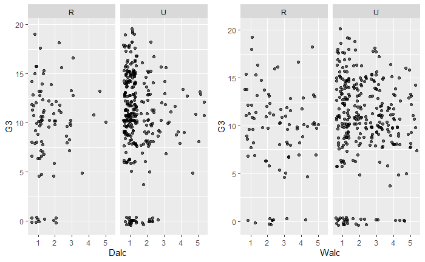

```r
Grades_Walc<-students_dataset %>%group_by(address)%>%ggplot(aes(x=factor(Walc), y= G3))+geom_jitter(alpha=0.6)+scale_x_discrete("Walc")+scale_y_continuous("G3")+facet_grid(~address)


grid.arrange(Grades_Dalc,Grades_Walc,ncol=2)
```

#4- 2 Perform t-tests to compare pairwise the mean of some quantitative variables depending on the two levels of some binary categorical variables.

```r
# Pairwise comparisons
test_students <- students_dataset%>%
  pairwise_t_test (
  G3 ~ sex  , pool.sd= T,
  p.adjust.method = "bonferroni",
  alternative = c("two.sided", "less", "greater"),

)
```

```r
stat.test <- students_dataset %>%
  group_by(.) %>%
  t_test(G3 ~ address, p.adjust.method = "bonferroni")

stat.test
```

|  | .y. | group1 | group2 | n1 | n2 | statistic | df | p |
| --- | --- | --- | --- | --- | --- | --- | --- | --- |
| 1 | G3 | R | U | 88 | 307 | -2.110137 | 140.9082 | 0.0366 |

# Create the plot

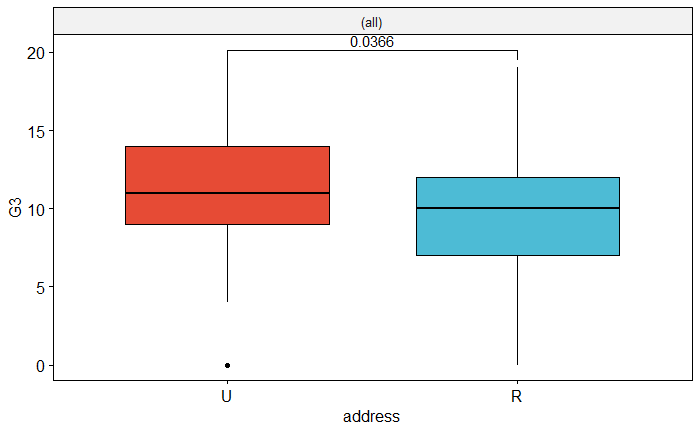

```r
myplot <- ggboxplot(
  students_dataset, x = "address", y = "G3",
  fill = "address", palette = "npg", legend = "none",
  ggtheme = theme_pubr(border = TRUE)
  ) +
  facet_wrap(~.)
# Add statistical test p-values
stat.test <- stat.test %>% add_xy_position(x = "address")
myplot + stat_pvalue_manual(stat.test)
```

# 4-3 Perform ANOVA to compare the mean of some quantitative variables depending on the levels of some non binary categorical variables.

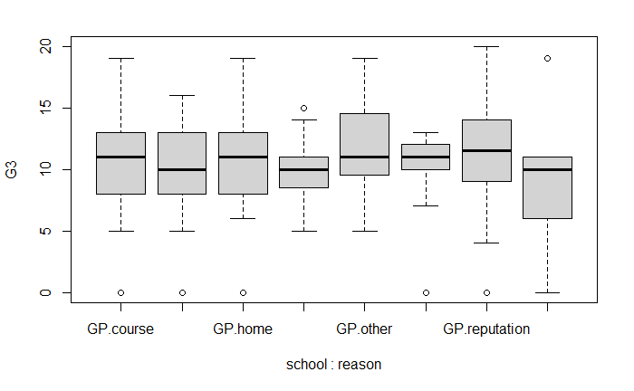

```r
boxplot( G3 ~ school * reason , data = students_dataset) + theme(axis.text.x = element_text(angle = 60 ))
```

Analayse of variance

```r
aov1 <- aov(G3 ~ Mjob*Fjob, data = students_dataset)
summary(aov1)
```

```
             Df Sum Sq Mean Sq F value  Pr(>F)
Mjob          4    307   76.66   3.744 0.00532 **
Fjob          4     67   16.68   0.815 0.51648
Mjob:Fjob    15    299   19.95   0.974 0.48215
Residuals   371   7597   20.48
---
Signif. codes:  0 ‘***’ 0.001 ‘**’ 0.01 ‘*’ 0.05 ‘.’ 0.1 ‘ ’ 1
```

```r
#table effects
model.tables(aov1)
```

```
Tables of effects

 Mjob
    at_home health    other services teacher
     -1.263  1.732  -0.5925   0.6042  0.6365
rep  59.000 34.000 141.0000 103.0000 58.0000

 Fjob
     at_home health     other services teacher
     0.07994  0.549  -0.05989  -0.3182    1.27
rep 20.00000 18.000 217.00000 111.0000   29.00

 Mjob:Fjob
          Fjob
Mjob       at_home health other  services teacher
  at_home    3.02    1.72  -0.25  -0.09    -7.53
  rep        7.00    2.00  33.00  15.00     2.00
  health             0.79  -0.47   0.58    -2.46
  rep        0.00    6.00  17.00  10.00     1.00
  other     -0.73    1.56   0.01  -0.05     0.14
  rep        5.00    2.00 104.00  24.00     6.00
  services  -2.95   -1.38   0.38   0.03     0.75
  rep        6.00    4.00  42.00  43.00     8.00
  teacher    0.07   -1.44  -0.03  -0.24     0.89
  rep        2.00    4.00  21.00  19.00    12.00
```

give tables of the mean response for each combinations of levels of the factors in a term

```r
model.tables(aov1, "means" )
```

```
Tables of means
Grand mean

10.41519

 Mjob
    at_home health   other services teacher
      9.153  12.15   9.823    11.02   11.05
rep  59.000  34.00 141.000   103.00   58.00

 Fjob
    at_home health  other services teacher
       10.5  10.96  10.36     10.1   11.69
rep    20.0  18.00 217.00    111.0   29.00

 Mjob:Fjob
          Fjob
Mjob       at_home health other  services teacher
  at_home   12.29   11.50   8.88   8.80     3.00
  rep        7.00    2.00  33.00  15.00     2.00
  health            13.50  11.59  12.40    11.00
  rep        0.00    6.00  17.00  10.00     1.00
  other      9.20   12.00   9.80   9.50    11.33
  rep        5.00    2.00 104.00  24.00     6.00
  services   8.17   10.25  11.36  10.77    13.13
  rep        6.00    4.00  42.00  43.00     8.00
  teacher   11.00   10.00  10.76  10.32    13.08
  rep        2.00    4.00  21.00  19.00    12.00
```

```r
# Post-hoc test or after the fact test to see which of these differences are statistically significant among the different conditions.
TukeyHSD(aov1)
```

```
  Tukey multiple comparisons of means
    95% family-wise confidence level

Fit: aov(formula = G3 ~ Mjob * Fjob, data = students_dataset)

$Mjob
                        diff        lwr        upr     p adj
health-at_home    2.99451645  0.3235543 5.66547858 0.0191809
other-at_home     0.67015266 -1.2532542 2.59355950 0.8748638
services-at_home  1.86687510 -0.1584960 3.89224621 0.0869487
teacher-at_home   1.89918177 -0.3945607 4.19292420 0.1571286
other-health     -2.32436379 -4.6944368 0.04570925 0.0575859
services-health  -1.12764135 -3.5811858 1.32590312 0.7159697
teacher-health   -1.09533469 -3.7747015 1.58403216 0.7956046
services-other    1.19672244 -0.4111754 2.80462033 0.2489131
teacher-other     1.22902910 -0.7060321 3.16409031 0.4100707
teacher-services  0.03230666 -2.0041354 2.06874868 0.9999992

$Fjob
                       diff        lwr      upr     p adj
health-at_home    0.4690949 -3.5611577 4.499348 0.9977496
other-at_home    -0.1398278 -3.0386463 2.758991 0.9999309
services-at_home -0.3981470 -3.4115060 2.615212 0.9963141
teacher-at_home   1.1902563 -2.4153289 4.795842 0.8949285
other-health     -0.6089227 -3.6516255 2.433780 0.9820700
services-health  -0.8672419 -4.0192609 2.284777 0.9433070
teacher-health    0.7211614 -3.0010874 4.443410 0.9841123
services-other   -0.2583192 -1.7058816 1.189243 0.9883368
teacher-other     1.3300841 -1.1225367 3.782705 0.5718491
teacher-services  1.5884033 -0.9985897 4.175396 0.4456634

$`Mjob:Fjob`
                                            diff        lwr       upr     p adj
health:at_home-at_home:at_home                NA         NA        NA        NA
other:at_home-at_home:at_home      -3.085714e+00 -12.853102  6.681673 0.9999846
services:at_home-at_home:at_home   -4.119048e+00 -13.399494  5.161399 0.9959684
teacher:at_home-at_home:at_home    -1.285714e+00 -14.660261 12.088832 1.0000000
at_home:health-at_home:at_home     -7.857143e-01 -14.160261 12.588832 1.0000000
health:health-at_home:at_home       1.214286e+00  -8.066160 10.494732 1.0000000
other:health-at_home:at_home       -2.857143e-01 -13.660261 13.088832 1.0000000
```

[output cut: 229 more lines]

```
health:services-services:other      1.042857e+00  -4.826612  6.912327 1.0000000
other:services-services:other      -1.857143e+00  -6.125527  2.411242 0.9969592
services:services-services:other   -5.897010e-01  -4.208566  3.029164 1.0000000
teacher:services-services:other    -1.041353e+00  -5.653311  3.570604 1.0000000
at_home:teacher-services:other     -8.357143e+00 -20.429957  3.715671 0.6556555
health:teacher-services:other      -3.571429e-01 -17.235548 16.521262 1.0000000
other:teacher-services:other       -2.380952e-02  -7.303990  7.256371 1.0000000
services:teacher-services:other     1.767857e+00  -4.666975  8.202689 0.9999989
teacher:teacher-services:other      1.726190e+00  -3.733945  7.186326 0.9999844
at_home:services-teacher:other     -1.961905e+00  -7.601109  3.677299 0.9999134
health:services-teacher:other       1.638095e+00  -4.770945  8.047136 0.9999997
other:services-teacher:other       -1.261905e+00  -6.246304  3.722494 0.9999998
services:services-teacher:other     5.537099e-03  -4.435332  4.446406 1.0000000
teacher:services-teacher:other     -4.461153e-01  -5.727714  4.835483 1.0000000
 [ reached getOption("max.print") -- omitted 50 rows ]
```